# ROMANTIC EVOLUTION/S - Die Hamburgische Staatsoper

[Die Hamburgische Staatsoper](https://www.die-hamburgische-staatsoper.de/de)

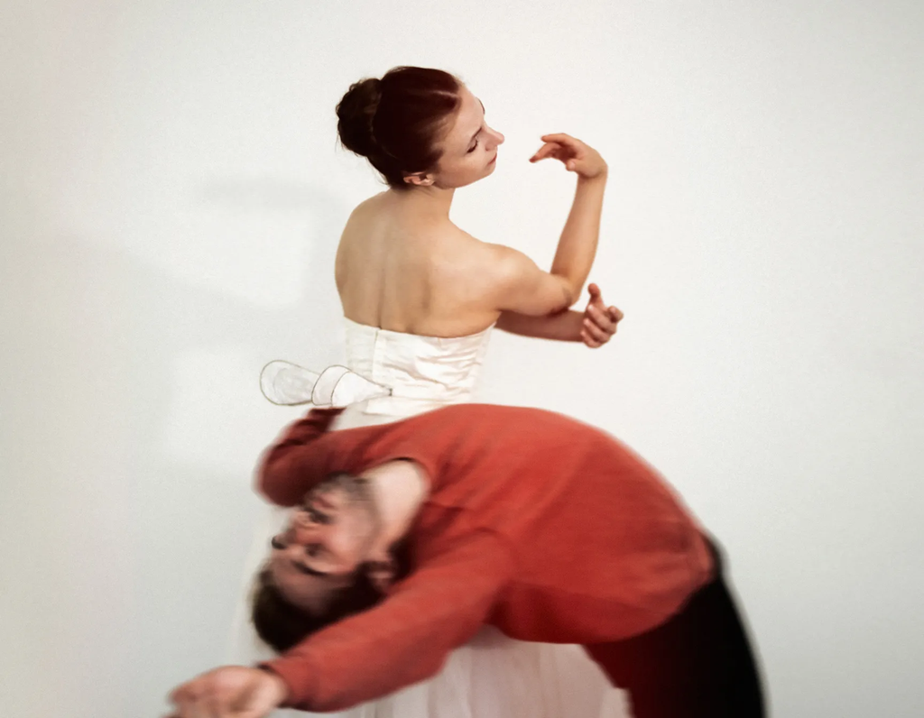

Kiran West

[Programm](https://hamburgballett.die-hamburgische-staatsoper.de/de/programm/) → Ballett

# ROMANTIC EVOLUTION/S

Bournonville / Martínez

- Premiere

  So 7.12. 18:00 Tickets
- Di 9.12. 19:30 Tickets
- Fr 12.12. 19:30 Tickets
- Di 16.12. 19:30 Tickets
- Mi 17.12. 19:30 Tickets
- Do 8.1. 19:30 Tickets
- Fr 9.1. 19:30 Tickets
- Do 5.2. 19:30 Tickets
- Fr 6.2. 19:30 Tickets
- Do 12.2. 19:30 Tickets
- Sa 4.7. 20:00 Tickets

*La Sylphide* gilt als Inbegriff des Romantischen Balletts, die Premiere im Jahr 1832 als Geburtsstunde der Kunstform. Seither entwickelt sich die Gattung Ballett stets weiter: Uraufführungen dienen seit fast 200 Jahren der Erneuerung und Erweiterung einer universellen Sprache, die ohne Worte auskommt, aber äußerst beredsam ist. Der Ballettabend *ROMANTIC EVOLUTION/S* vereint nun eines der ältesten Ballette - *La Sylphide* - mit einer Uraufführung des Ersten Solisten und Choreografen Aleix Martínez. Im Auftrag von Interims-Ballettdirektor Lloyd Riggins, wird sich Martínez von diesem romantischen Klassiker für sein neues Stück inspirieren lassen.

## IRDISCH / ÜBERIRDISCH

### La Sylphide

- Uraufführung: 28. Nov. 1836, Königlich Dänisches Ballett, Kopenhagen  
  Premiere beim Hamburg Ballett: Hamburgische Staatsoper, 7. Dezember 2025

### Äther

- Uraufführung: Hamburg Ballett, Hamburgische Staatsoper, 7. Dezember 2025  
  Premiere des Ballettabends ROMANTIC EVOLUTION/S: Hamburg Ballett, Hamburgische Staatsoper, 7. Dezember 2025

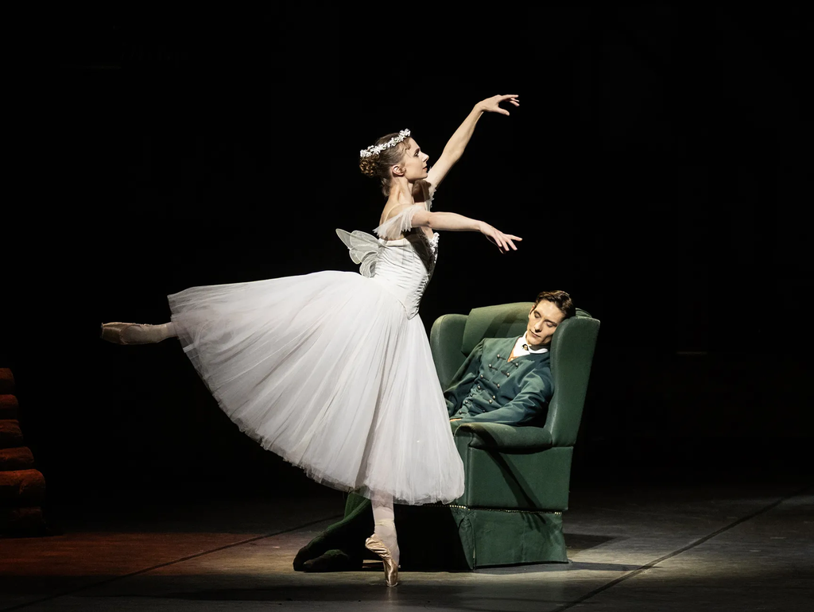

- **© ×**

  Kiran West

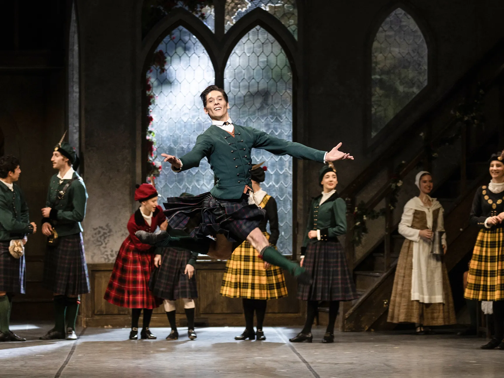

- **© ×**

  Kiran West

[figure not shown]

- **© ×**

  Kiran West

[figure not shown]

- **© ×**

  Kiran West

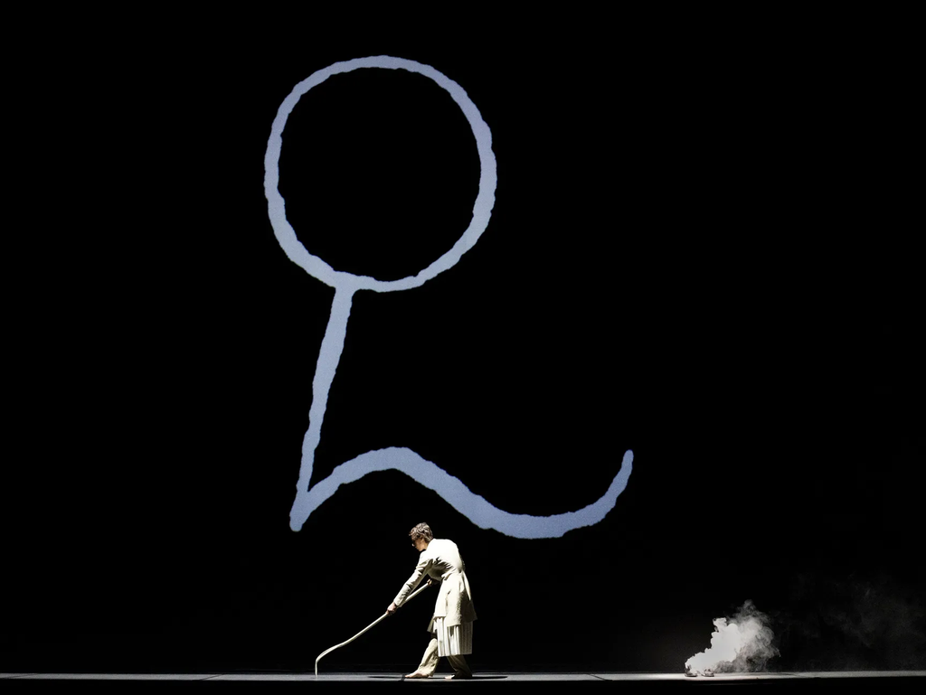

- **© ×**

  Kiran West

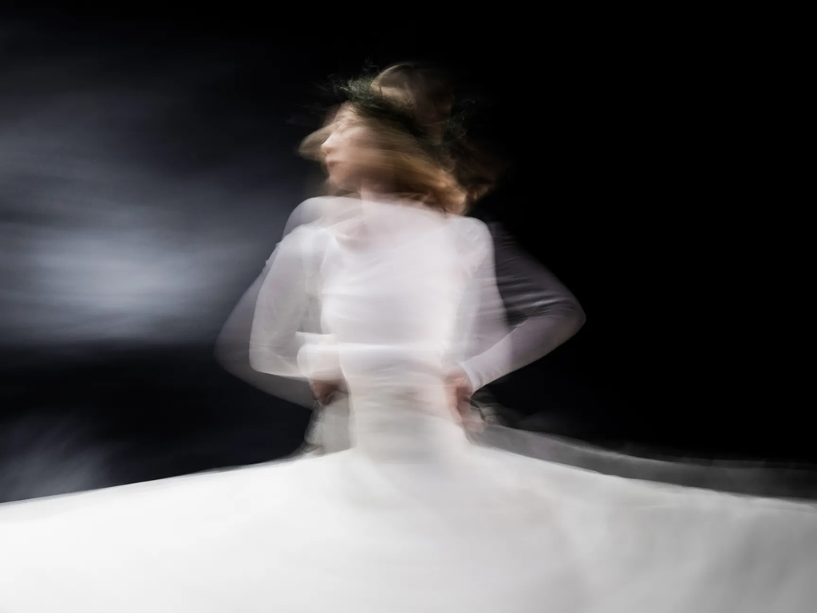

- **© ×**

  Kiran West

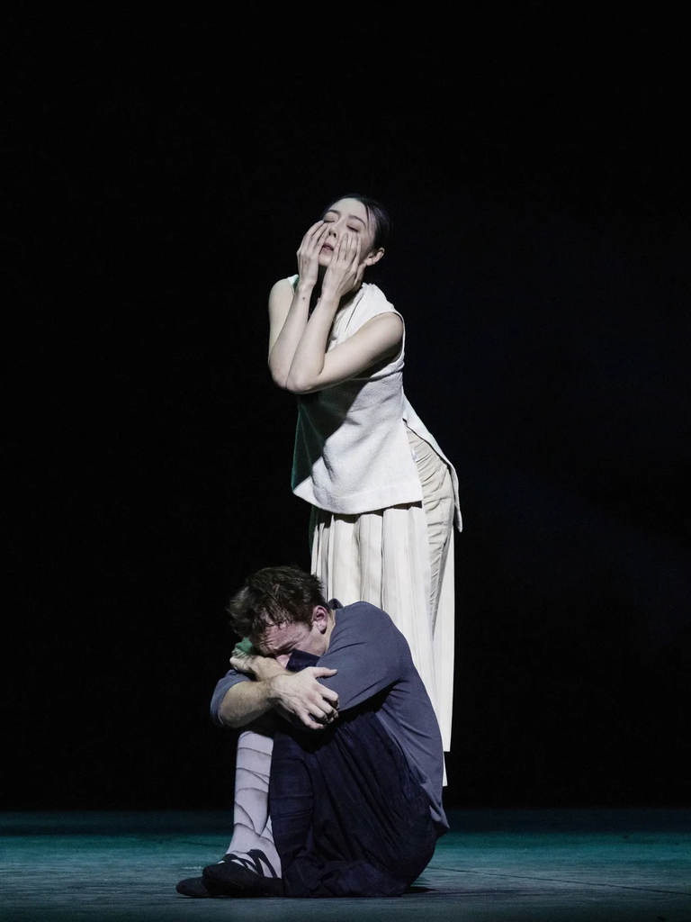

- **© ×**

  Kiran West

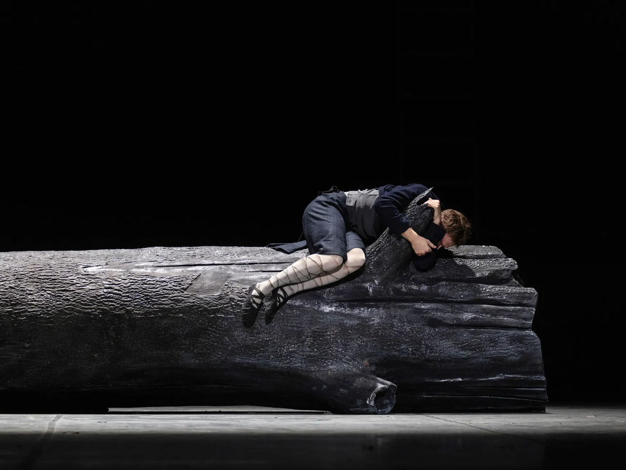

- **© ×**

  Kiran West

## Besetzung

- Musikalische Leitung

  [Markus Lehtinen](https://hamburgballett.die-hamburgische-staatsoper.de/de/personen/662-markus-lehtinen)
- Ensemble

  Hamburg Ballett
- Orchester

  [Philharmonisches Staatsorchester Hamburg](https://hamburgballett.die-hamburgische-staatsoper.de/de/personen/1929-philharmonisches-staatsorchester-hamburg)

**La Sylphide − +**

- Choreografie

  August Bournonville
- Musik

  Herman Severin Løvenskjold
- Inszenierung und Einstudierung

  Frank Andersen

  Eva Kloborg
- Bühne und Kostüme

  Mikael Melbye
- Licht

  Jesper Kongshaug
- Ballettmeister

  Sebastian Kloborg
- Ballettmeisterin

  Anne-Marie Vessel-Schlüter

**Äther − +**

- Choreografie

  Aleix Martínez
- Bühnenbild

  Aleix Martínez
- Kostüme

  Lennart Radtke
- Musik

  Peteris Vasks

  Arvo Pärt

  Arnau Obiols
- Filmarbeit

  Kiran West
- Lichtkonzept

  Aleix Martínez
- Solo-Violine

  [Anton Barakhovsky](https://hamburgballett.die-hamburgische-staatsoper.de/de/personen/3722-anton-barakhovsky)
  - 7.12.25 /
  - 9.12.25 /
  - 5.2.26 /
  - 6.2.26 /
  - 12.2.26 /
  - 4.7.26

  [Valeriy Sokolov](https://hamburgballett.die-hamburgische-staatsoper.de/de/personen/2147496085-valeriy-sokolov)
  - 12.12.25 /
  - 16.12.25 /
  - 17.12.25 /
  - 8.1.26 /
  - 9.1.26

## Das Stück

- Spielstätte Staatsoper, Großes Haus
- Pause 2 Pausen je 25 Min. / 1. Akt: ca. 35 Minuten, 2. Akt: ca. 40 Minuten, 3. Akt: ca. 50 Minuten / Dauer ca. 3 Stunden
- Altersempfehlung ab 10 Jahren / Klasse 5

*La Sylphide* dreht sich um den schottischen Bauern James der sich am Tag seiner Hochzeit in eine Sylphide verliebt. Dieser ätherische Luftgeist – den er nicht einfangen kann – bezaubert ihn so sehr, dass er sein Haus und seine Verlobte verlässt um ihr in den Wald zu folgen. Mithilfe der Hexe Madge schafft er es endlich, Besitz von der Sylphide zu ergreifen, woraufhin diese aber stirbt.  
Dieses charmante Ballett hat nicht nur wegen seiner grazilen, schwebenden Sylphiden, seine mondbeschienene Waldlichtung und seiner pittoresken, folkloristischen Tanzeinlagen in James‘ Bauernhaus fast zwei Jahrhunderte überlebt, sondern auch wegen seiner zeitlosen Themen: der Beziehung zwischen Mensch und Natur, der Faszination, die das Übernatürliche auf uns ausübt und der Dichotomie zwischen unserem alltäglichen, banalen irdischen Leben und der spirituellen Welt. Martínez wird in seiner Uraufführung einige dieser Themen in seinem neuen Stück aufgreifen.  
Die Choreografie von *La Sylphide* stammt von August Bournonville, dessen Name unzertrennlich mit dem des Königlich Dänischen Balletts verbunden ist. Bournonvilles Fassung aus dem Jahr 1836 gilt bis heute als maßgeblich. Die Einstudierung in Hamburg übernimmt Frank Andersen, einst Direktor des Königlich Dänischen Balletts gemeinsam mit Eva Kloborg. Beide zählen zu den weltweit führenden Bournonville-Spezialisten. Auf Einladung von Lloyd Riggins – der selbst auch Erster Solist des Königlich Dänischen Balletts war - werden Andersen und Kloborg den besonderen Stil und Charme von Bournonvilles weltberühmtem Ballett den Tänzer:innen des Hamburg Balletts beibringen.

- Mit freundlicher Unterstützung durch die

[figure not shown]

**Onlineshop − +**

Das Programmheft zu *ROMANTIC EVOLUTION/S* ist ab dem Premierentag erhältlich. Bereits jetzt können Sie das [Produktionsplakat](https://hamburgballett-shop.de/p/poster-romantic-evolution-s-1) in A1 zu *ROMANTIC EVOLUTION/S* in unserem Onlineshop erwerben.

DOSSIER

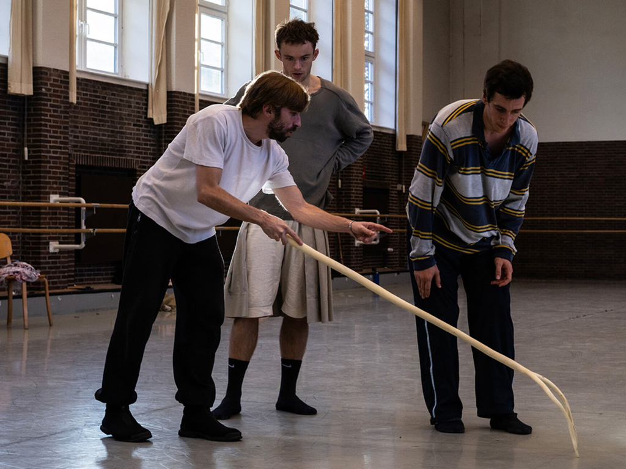

NDR Kultur

Choreograf Aleix Martínez im Interview zu seiner Kreation "Äther" – Annette Matz berichtet für NDR Kultur aus den Proben

[Zum Beitrag](https://www.ndr.de/kultur/buehne/taenzer-aleix-martinez-choreografiert-fuer-hamburg-ballett,aleixmartinez-100.html)

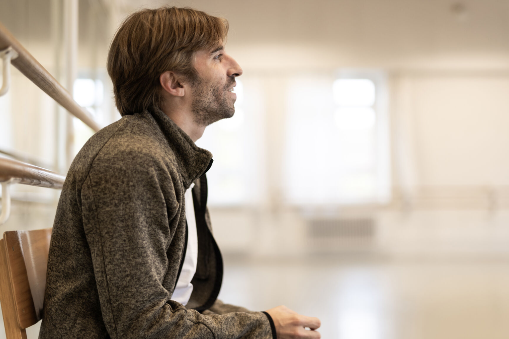

NDR Hamburg Journal

Annette Yang berichtet für das NDR Hamburg Journal aus den Proben zu Äther und trifft Choreograf Aleix Martínez sowie Kostümbildner Lennart Radtke. Ausgabe vom 19.11.2025

[Hier ansehen](https://www.ardmediathek.de/video/hamburg-journal/neue-talente-beim-hamburg-ballett-im-portraet/ndr/Y3JpZDovL25kci5kZS83NGNjMGIzNC1mYjcwLTQ2ZDctOWUzZS1hOTc0MDg0YmY2ZGI)

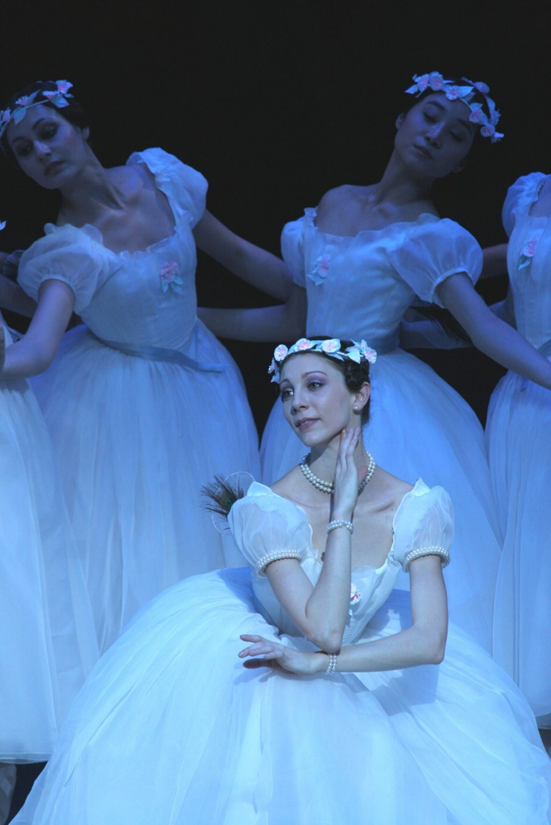

Was ist eine Sylphide?

Nathalia Schmidt geht den mystischen Wesen der Sylphiden auf die Spur

[Hier lesen](https://hamburgballett.die-hamburgische-staatsoper.de/de/artikel/was-ist-eine-sylphide)

[figure not shown]

La Sylphide: Das Ur-Ballett

1832 schrieb sich „La Sylphide“ in die Tanzgeschichte ein - Ein faszinierender Blick auf den Abend, der die Ballerina zum schwebenden Ideal erhob.

Von Vivien Arnold

[Hier lesen](https://hamburgballett.die-hamburgische-staatsoper.de/de/artikel/la-sylphide-das-ur-ballett)

- - La Sylphide
  - Äther

    Aleix Martínez

  Mit: [Markus Lehtinen](https://hamburgballett.die-hamburgische-staatsoper.de/de/personen/662-markus-lehtinen), [Anton Barakhovsky](https://hamburgballett.die-hamburgische-staatsoper.de/de/personen/3722-anton-barakhovsky), Hamburg Ballett, [Philharmonisches Staatsorchester Hamburg](https://hamburgballett.die-hamburgische-staatsoper.de/de/personen/1929-philharmonisches-staatsorchester-hamburg)

  [Premieren-Abo (PrA)](https://www.die-hamburgische-staatsoper.de/de/service/abos#premieren-abos) · 8€ 17€ 30€ 55€ 88€ 124€ 149€ 174€ 191€ 207€

  [Details](https://hamburgballett.die-hamburgische-staatsoper.de/de/programm/ballett/2147484877-romantic-evolution-s)
- - La Sylphide
  - Äther

    Aleix Martínez

  Mit: [Anton Barakhovsky](https://hamburgballett.die-hamburgische-staatsoper.de/de/personen/3722-anton-barakhovsky), Hamburg Ballett, [Markus Lehtinen](https://hamburgballett.die-hamburgische-staatsoper.de/de/personen/662-markus-lehtinen), [Philharmonisches Staatsorchester Hamburg](https://hamburgballett.die-hamburgische-staatsoper.de/de/personen/1929-philharmonisches-staatsorchester-hamburg)

  [Premieren-Abo (PrB)](https://www.die-hamburgische-staatsoper.de/de/service/abos#premieren-abos) · 7€ 13€ 21€ 38€ 56€ 71€ 83€ 94€ 105€ 119€

  [Details](https://hamburgballett.die-hamburgische-staatsoper.de/de/programm/ballett/2147484877-romantic-evolution-s)
- - La Sylphide
  - Äther

    Aleix Martínez

  Mit: [Valeriy Sokolov](https://hamburgballett.die-hamburgische-staatsoper.de/de/personen/2147496085-valeriy-sokolov), Hamburg Ballett, [Markus Lehtinen](https://hamburgballett.die-hamburgische-staatsoper.de/de/personen/662-markus-lehtinen), [Philharmonisches Staatsorchester Hamburg](https://hamburgballett.die-hamburgische-staatsoper.de/de/personen/1929-philharmonisches-staatsorchester-hamburg)

  [Wochentags-Abo (Fr1)](https://www.die-hamburgische-staatsoper.de/de/service/abos#wochentags-abos) · 7€ 15€ 23€ 41€ 62€ 77€ 91€ 103€ 115€ 129€

  [Details](https://hamburgballett.die-hamburgische-staatsoper.de/de/programm/ballett/2147484877-romantic-evolution-s)
- - La Sylphide
  - Äther

    Aleix Martínez

  Mit: [Valeriy Sokolov](https://hamburgballett.die-hamburgische-staatsoper.de/de/personen/2147496085-valeriy-sokolov), Hamburg Ballett, [Markus Lehtinen](https://hamburgballett.die-hamburgische-staatsoper.de/de/personen/662-markus-lehtinen), [Philharmonisches Staatsorchester Hamburg](https://hamburgballett.die-hamburgische-staatsoper.de/de/personen/1929-philharmonisches-staatsorchester-hamburg)

  [Ballett-Only-Abo (Ball2)](https://www.die-hamburgische-staatsoper.de/de/service/abos#ballett-only-abos) · 7€ 13€ 21€ 38€ 56€ 71€ 83€ 94€ 105€ 119€

  [Details](https://hamburgballett.die-hamburgische-staatsoper.de/de/programm/ballett/2147484877-romantic-evolution-s)
- - La Sylphide
  - Äther

    Aleix Martínez

  Mit: [Valeriy Sokolov](https://hamburgballett.die-hamburgische-staatsoper.de/de/personen/2147496085-valeriy-sokolov), Hamburg Ballett, [Markus Lehtinen](https://hamburgballett.die-hamburgische-staatsoper.de/de/personen/662-markus-lehtinen), [Philharmonisches Staatsorchester Hamburg](https://hamburgballett.die-hamburgische-staatsoper.de/de/personen/1929-philharmonisches-staatsorchester-hamburg)

  [Wochentags-Abo (Mi1)](https://www.die-hamburgische-staatsoper.de/de/service/abos#wochentags-abos) · 7€ 13€ 21€ 38€ 56€ 71€ 83€ 94€ 105€ 119€

  [Details](https://hamburgballett.die-hamburgische-staatsoper.de/de/programm/ballett/2147484877-romantic-evolution-s)
- - La Sylphide
  - Äther

    Aleix Martínez

  Mit: [Valeriy Sokolov](https://hamburgballett.die-hamburgische-staatsoper.de/de/personen/2147496085-valeriy-sokolov), Hamburg Ballett, [Markus Lehtinen](https://hamburgballett.die-hamburgische-staatsoper.de/de/personen/662-markus-lehtinen), [Philharmonisches Staatsorchester Hamburg](https://hamburgballett.die-hamburgische-staatsoper.de/de/personen/1929-philharmonisches-staatsorchester-hamburg)

  [Weihnachtsgeschenk-Abo (GeschBall)](https://www.die-hamburgische-staatsoper.de/de/service/abos#geschenk-abos) · 7€ 13€ 21€ 38€ 56€ 71€ 83€ 94€ 105€ 119€

  [Details](https://hamburgballett.die-hamburgische-staatsoper.de/de/programm/ballett/2147484877-romantic-evolution-s)
- - La Sylphide
  - Äther

    Aleix Martínez

  Mit: [Markus Lehtinen](https://hamburgballett.die-hamburgische-staatsoper.de/de/personen/662-markus-lehtinen), [Valeriy Sokolov](https://hamburgballett.die-hamburgische-staatsoper.de/de/personen/2147496085-valeriy-sokolov), Hamburg Ballett, [Philharmonisches Staatsorchester Hamburg](https://hamburgballett.die-hamburgische-staatsoper.de/de/personen/1929-philharmonisches-staatsorchester-hamburg)

  [Ballett-Only-Abo (Ball1)](https://www.die-hamburgische-staatsoper.de/de/service/abos#ballett-only-abos) · 7€ 15€ 23€ 41€ 62€ 77€ 91€ 103€ 115€ 129€

  [Details](https://hamburgballett.die-hamburgische-staatsoper.de/de/programm/ballett/2147484877-romantic-evolution-s)
- - La Sylphide
  - Äther

    Aleix Martínez

  Mit: [Anton Barakhovsky](https://hamburgballett.die-hamburgische-staatsoper.de/de/personen/3722-anton-barakhovsky), Hamburg Ballett, [Markus Lehtinen](https://hamburgballett.die-hamburgische-staatsoper.de/de/personen/662-markus-lehtinen), [Philharmonisches Staatsorchester Hamburg](https://hamburgballett.die-hamburgische-staatsoper.de/de/personen/1929-philharmonisches-staatsorchester-hamburg)

  [Ballett-Only-Abo (BallKl2)](https://www.die-hamburgische-staatsoper.de/de/service/abos#ballett-only-abos) · 7€ 13€ 21€ 38€ 56€ 71€ 83€ 94€ 105€ 119€

  [Details](https://hamburgballett.die-hamburgische-staatsoper.de/de/programm/ballett/2147484877-romantic-evolution-s)
- - La Sylphide
  - Äther

    Aleix Martínez

  Mit: [Anton Barakhovsky](https://hamburgballett.die-hamburgische-staatsoper.de/de/personen/3722-anton-barakhovsky), Hamburg Ballett, [Markus Lehtinen](https://hamburgballett.die-hamburgische-staatsoper.de/de/personen/662-markus-lehtinen), [Philharmonisches Staatsorchester Hamburg](https://hamburgballett.die-hamburgische-staatsoper.de/de/personen/1929-philharmonisches-staatsorchester-hamburg)

  [Wochentags-Abo (Fr2)](https://www.die-hamburgische-staatsoper.de/de/service/abos#wochentags-abos) · [Wochentags-Abo (FrKl)](https://www.die-hamburgische-staatsoper.de/de/service/abos#wochentags-abos) · 7€ 15€ 23€ 41€ 62€ 77€ 91€ 103€ 115€ 129€

  [Details](https://hamburgballett.die-hamburgische-staatsoper.de/de/programm/ballett/2147484877-romantic-evolution-s)
- - La Sylphide
  - Äther

    Aleix Martínez

  Mit: [Anton Barakhovsky](https://hamburgballett.die-hamburgische-staatsoper.de/de/personen/3722-anton-barakhovsky), Hamburg Ballett, [Markus Lehtinen](https://hamburgballett.die-hamburgische-staatsoper.de/de/personen/662-markus-lehtinen), [Philharmonisches Staatsorchester Hamburg](https://hamburgballett.die-hamburgische-staatsoper.de/de/personen/1929-philharmonisches-staatsorchester-hamburg)

  [Wochentags-Abo (VTg1)](https://www.die-hamburgische-staatsoper.de/de/service/abos#wochentags-abos) · [Weihnachtsgeschenk-Abo (GeschOpBall)](https://www.die-hamburgische-staatsoper.de/de/service/abos#geschenk-abos) · 7€ 13€ 21€ 38€ 56€ 71€ 83€ 94€ 105€ 119€

  [Details](https://hamburgballett.die-hamburgische-staatsoper.de/de/programm/ballett/2147484877-romantic-evolution-s)
- - La Sylphide
  - Äther

    Aleix Martínez

  Mit: Hamburg Ballett, [Anton Barakhovsky](https://hamburgballett.die-hamburgische-staatsoper.de/de/personen/3722-anton-barakhovsky), [Markus Lehtinen](https://hamburgballett.die-hamburgische-staatsoper.de/de/personen/662-markus-lehtinen), [Philharmonisches Staatsorchester Hamburg](https://hamburgballett.die-hamburgische-staatsoper.de/de/personen/1929-philharmonisches-staatsorchester-hamburg)

  [Happy-Weekend-Abo (Sa3)](https://www.die-hamburgische-staatsoper.de/de/service/abos#happy-weekend-abos) · 7€ 15€ 25€ 45€ 71€ 97€ 109€ 121€ 135€ 147€

  [Details](https://hamburgballett.die-hamburgische-staatsoper.de/de/programm/ballett/2147484877-romantic-evolution-s)

[interactive chart not shown]